# Language

2020-05-02 16:39:22

```r
library(tidyverse)
library(latex2exp)
```

# 1 Language

This section is based on (Bilaniuk 2009, Chapter 1)

The primary objective of propositional logic, $\mathcal{L}_P$, is to formalize the reasoning that can be done using connectives like *not*, *and*, *or* and *if … then*

**Definition** The symbols of $\mathcal{L}_P$ are

- Parentheses: $($ and $)$
- Connectives: $\neg$ and $\to$
- Atomic formulas: $A_0, A_1, A_2, \dots , A_n, \dots$

Now we specify how the symbols of $\mathcal{L}_P$ can be put together

**Definition** The formulas of $\mathcal{L}_P$ are any finite sequences of $\mathcal{L}_P$ symbols which satisfy the following rules

- Every atomic formula is a formula
- If $\alpha$ is a formula then $(\neg \alpha)$ is a formula
- If $\alpha$ and $\beta$ are formulas then $\alpha \to \beta$ is a formula
- No other sequence of symbols in $\mathcal{L}_P$ are formulas
  - The parentheses are used to group other symbols together
  - The atomic formulas represent statements that cannot be broken down any further using $\neg$ or $\rightarrow$
  - Every atomic formula is a formula and every other formula is built from shorter formulas using $\neg$, $\rightarrow$, $($ and $)$ in particular ways
  - The last part points out that there are exactly three rules to form formulas in $\mathcal{L}_P$

## 1.1 Problems 1-7 and solutions

**Problem 1** *Why are the following not formulas of $\mathcal{L}_P$? There might be more than one reason* $\dots$

- $A_{-56}$
  - $A_{ \color{red}{-56}}$ is not an atomic formula
- $(Y \to A)$
  - $\color{red}{Y}$ and $\color{red}{A}$ are not atomic formulas
- $(A_7 \leftarrow A_4)$
  - $\color{red}{\leftarrow}$ is not a connective
- $A_7 \to (\neg A_5))$
  - $($ is missing at the beginning of the sequence
    - $\color{red}{(}A_7 \to (\neg A_5))$
- $(A_8A_9 \to A_1043998$
  - $)$ is missing at the end of the sequence
    - $(A_8A_9 \to A_1043998 \color{red}{)}$
  - $\color{red}{A_8A_9}$ is not a formula
- $(((\lnot A_1) \to (A_\ell \to A_7) \to A_7)$
  - One $)$ is missing or $($ and $)$ are missing
    - $(((\lnot A_1) \to (A_\ell \to A_7) \color{red}{)} \to A_7)$
    - $(((\lnot A_1) \to \color{red}{(} (A_\ell \to A_7) \to A_7) \color{red}{)}$
  - $A_{\color{red}{\ell}}$ is not an atomic formula

**Problem 2** *Show that every formula of $\mathcal{L}_P$ has the same number of left parentheses as it has of right parentheses*

- Proof by strong induction where $n$ is the number of connectives in a formula of $\mathcal{L}_P$
  - *Base step* $(n = 0)$: If $\gamma$ is a formula with 0 connectives it must be an atomic formula. Therefore $\gamma$ has the same number of $($ and $)$.
  - *Induction hypothesis* $(n \leq k)$: If $\gamma$ is a formula with $n \leq k$ connectives then it has the same number of $($ and $)$.
  - *Induction step* $(n = k + 1)$: If $\gamma$ is a formula with $n = k + 1$ connectives then we have two possibilities:
    - $\gamma = (\neg \alpha)$ where $\alpha$ has $n = k$ connectives
    - $\gamma = (\alpha \to \beta)$ where $\alpha$ and $\beta$ have $n \leq k$ connectives
      - If $\gamma = (\neg \alpha)$ then by the *induction hypothesis* $\alpha$ has the same number of $($ and $)$. Therefore $\gamma$ also has the same number of $($ and $)$
      - If $\gamma = (\alpha \to \beta)$ then by the *induction hypothesis* $\alpha$ and $\beta$ has the same number of $($ and $)$. Therefore $\gamma$ also has the same number of $($ and $)$

**Problem 3** *Suppose $\alpha$ is any formula of $\mathcal{L}_P$. Let $\ell(\alpha)$ be the length of $\alpha$ as a sequence of symbols and let $p(\alpha)$ be the number of parentheses (counting both left and right parentheses) in $\alpha$. What are the minimum and maximum values of $p(\alpha) / \ell(\alpha)$?*

- The minimum values of $p(\alpha)$ and $\ell(\alpha)$ are 0 and 1 which is the case when $\alpha$ is an atomic formula. Therefore the minimum value of $p(\alpha) / \ell(\alpha)$ is 0
- To find the maximum value of $p(\alpha) / \ell(\alpha)$ it is important to point out that:
  - $\ell(\alpha) = p(\alpha) + c(\alpha) + a(\alpha)$ where $c(\alpha)$ and $a(\alpha)$ are the number of connectives and atomic formulas in $\alpha$
  - $p(\alpha) = 2c(\alpha)$
  - To maximize $p(\alpha) / \ell(\alpha)$ we need to minimize $\ell(\alpha)$ by choosing the minimum value of $a(\alpha)$
    - The minimum value of $a(\alpha)$ is 1 and corresponds to formulas built from negating a formula at each step and starting with an atomic formula: $A_0, (\neg A_0), (\neg (\neg A_0)), \dots$
    - For this case we have that $p(\alpha) / \ell(\alpha) = \frac{2c(\alpha)}{3c(\alpha) + 1}$ where $c(\alpha) \in \{ 0, 1, 2, \dots, n\}$
      - $p(\alpha) / \ell(\alpha)$ doesn’t have a maximum but when $c(\alpha) \to \infty$ then $p(\alpha) / \ell(\alpha) \to 2 /3 \approx 0.667$

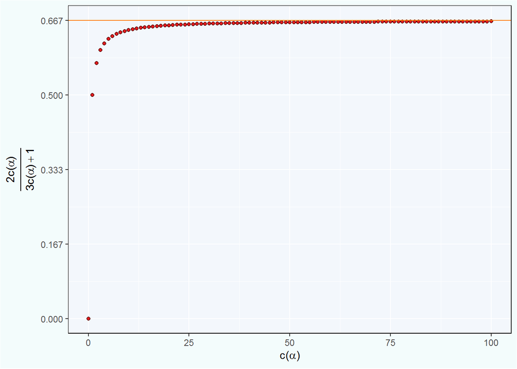

```r
ggplot(tibble(x = 0:100), aes(x)) +
    stat_function(fun   = ~ 2 * .x / (3 * .x + 1) ,
                  geom  = "point",
                  shape = 21,
                  fill  = "#E31A1C") +
    geom_hline(yintercept = 2/3,
               color      = "#FF7F00") +
    scale_y_continuous(breaks = seq(0, 4/6, 1/6),
                       labels = scales::number_format(accuracy = 0.001)) +
    labs(x = TeX("$c(\\alpha)$"),
         y = TeX("$\\frac{2c(\\alpha)}{3c(\\alpha) + 1}$"))  +
    theme(panel.border      = element_rect(fill = NA, color = "black"),
          plot.background   = element_rect(fill = "#f3fcfc"),
          panel.background  = element_rect(fill = "#f3f7fc"))
```

**Problem 4** *Suppose $\alpha$ is any formula of $\mathcal{L}_P$. Let $a(\alpha)$ be the number of atomic formulas in $\alpha$ (counting repetitions) and let $c_{\to}(\alpha)$ be the number of occurrences of $\to$ in $\alpha$. Show that $a(\alpha) = c_{\to}(\alpha) + 1$.*

**Problem 5** *What are the possible lengths of formulas of $\mathcal{L}_P$? Prove it.*

Therefore we can see that the possible lengths of formulas of $\mathcal{L}_P$ are $1, 4, 5$ and $7, 8, 9, 10, \dots, n$

**Problem 6** *Find a way for doing without parentheses or other punctuation symbols in defining a formal language for propositional logic.*

A possible way is to use the *polish notation* invented by Jan Lukasiewicz as mentioned in (Church 1956, p 38). Another option is to use *reverse polish notation* used in some Hewlett-Packard calculators

- In our case *polish notation* is apply in the following way:
  - $(\alpha \to \beta)$ can be written as $\to \alpha \beta$
  - $(\neg \alpha)$ can be written as $\neg \alpha$
    - For example $((\neg \alpha) \to \beta)$, $(\alpha \to (\neg \beta))$, $((\neg \alpha) \to (\neg \beta))$, $(\neg (\alpha \to \beta))$, $(\neg ( (\neg \alpha) \to \beta))$, $(\neg ( \alpha \to (\neg \beta)))$ and $(\neg ( (\neg \alpha) \to (\neg \beta)))$ are written as:
      - $\to \neg \alpha \beta$
      - $\to \alpha \neg \beta$
      - $\to \neg \alpha \neg \beta$
      - $\neg \to \alpha \beta$
      - $\neg \to \neg \alpha \beta$
      - $\neg \to \alpha \neg \beta$
      - $\neg \to \neg \alpha \neg \beta$
- In our case *reverse polish notation* is apply in the following way:
  - $(\alpha \to \beta)$ can be written as $\alpha \beta \to$
  - $(\neg \alpha)$ can be written as $\alpha \neg$
    - For example $((\neg \alpha) \to \beta)$, $(\alpha \to (\neg \beta))$, $((\neg \alpha) \to (\neg \beta))$, $(\neg (\alpha \to \beta))$, $(\neg ( (\neg \alpha) \to \beta))$, $(\neg ( \alpha \to (\neg \beta)))$ and $(\neg ( (\neg \alpha) \to (\neg \beta)))$ are written as:
      - $\alpha \neg \beta \to$
      - $\alpha \beta \neg \to$
      - $\alpha \neg \beta \neg \to$
      - $\alpha \beta \to \neg$
      - $\alpha \neg \beta \to \neg$
      - $\alpha \beta \neg \to \neg$
      - $\alpha \neg \beta \neg \to \neg$

**Problem 7** *Show that the set of formulas of $\mathcal{L}_P$ is countable.*

Let’s define the following sets

- $S_{\mathcal{L}_P} = \{ (, ), \neg, \to, A_0, A_1, A_2, \dots, A_n, \dots \}$ the set of symbols of $\mathcal{L}_P$
  - Because $\{ A_0, A_1, A_2, \dots, A_n, \dots \}$ is countable then $S_{\mathcal{L}_P}$ is countable
    - $S_{\mathcal{L}_P}^i = \underbrace{S_{\mathcal{L}_P} \times \dots \times S_{\mathcal{L}_P}}_\text{i times}$ for $i = 1, 4, 5, 7, 8, 9, 10, \dots, n$ are countable
      - $S_{\mathcal{L}_P} = \bigcup_{i = 1}^n S_{\mathcal{L}_P}^i$ is also countable
- $F_{\mathcal{L}_P \ell_i}$ the formulas of $\mathcal{L}_P$ separated by its individual components in a *i-tuple* where $i = 1, 4, 5, 7, 8, 9, 10, \dots, n$. Each $F_{\mathcal{L}_P \ell_i}$ represents the formulas of $\mathcal{L}_P$ with length $i$.
  - For example $(A_0 \to (\neg A_1))$ can be represented as $[ (, A_0, \to, (, \neg, A_1, ), ) ]$ where $[ (, A_0, \to, (, \neg, A_1, ), ) ] \in F_{\mathcal{L}_P \ell_8}$
    - $F_{\mathcal{L}_P} = \bigcup_{i = 1}^n F_{\mathcal{L}_P \ell_i}$
      - $F_{\mathcal{L}_P}$ is countable because $F_{\mathcal{L}_P} \subset S_{\mathcal{L}_P}$
- Therefore the set of formulas of $\mathcal{L}_P$ is countable

## 1.2 Informal Conventions I

We will use the symbols $\land$, $\lor$, and $\leftrightarrow$ to represent *and*, *or* and *if and only if*. Since they are not among the symbols of $\mathcal{L}_P$, we will use them as abbreviations for certain constructions involving only $\lnot$ and $\to$:

- $(\alpha \land \beta)$ is short for $(\neg (\alpha \to (\neg \beta)))$
- $(\alpha \lor \beta)$ is short for $((\neg \alpha) \to \beta)$
- $(\alpha \leftrightarrow \beta)$ is short for $((\alpha \to \beta) \land (\beta \to \alpha))$

## 1.3 Problems 8-9 and solutions

**Problem 8** *Take a couple of english sentences with several connectives and translate them into formulas of $\mathcal{L}_P$. You may use $\land$, $\lor$, and $\leftrightarrow$ if appropriate.*

- I will go to Peru or Argentina only if I am on vacations
  - $A_0$: I will go to Peru
  - $A_1$: I will go to Argentina
  - $A_2$: I am on vacations
    - $((A_0 \lor A_1) \leftrightarrow A_2)$
- If neither I nor you can do it then anyone can’t do it
  - $A_0$: I can do it
  - $A_1$: You can do it
  - $A_3$: Anyone can do it
    - $((\neg (A_0 \lor A_1)) \to (\neg A_3))$

**Problem 9** *Write out $((\alpha \lor \beta) \land (\beta \to \alpha))$ using only $\neg$ and $\to$.*

- $(\neg (((\neg \alpha) \to \beta) \to (\lnot (\beta \to \alpha))))$

## 1.4 Informal Conventions II

For the sake of readability, we will occasionally use some informal conventions that let us get away with writing fewer parentheses:

- We will usually drop the outermost parentheses in a formula
  - $\alpha \to \beta$ instead of $(\alpha \to \beta)$
- We will let $\neg$ take precedence over $\to$ when parentheses are missing
  - $\neg \alpha \to \beta$ instead of $((\neg \alpha) \to \beta)$
    - Also fit the informal connectives into this scheme by letting the order of precedence be $\neg, \land, \lor, \to$ and $\leftrightarrow$
- We will group repetitions of $\to, \lor, \land, \leftrightarrow$ to the right when parentheses are missing
  - $\alpha \to \beta \to \gamma$ instead of $(\alpha \to (\beta \to \gamma))$

## 1.5 Problems 10-11 and solutions

**Problem 10** Write out $\neg (\alpha \leftrightarrow \neg \delta ) \land \beta \to \neg \alpha \to \gamma$ first with the missing parentheses included and then as an official formula of $\mathcal{L}_P$.

- With parentheses
  - $(((\neg (\alpha \leftrightarrow (\neg \delta))) \land \beta) \to ((\neg \alpha) \to \gamma))$
- Using only $\mathcal{L}_P$ symbols
  - $((\neg ((\neg (\neg ((\alpha \to (\neg \delta)) \to (\neg ((\neg \delta) \to \alpha))))) \to (\neg \beta))) \to ((\neg \alpha) \to \gamma))$

**Definition** Suppose $\varphi$ is a formula of $\mathcal{L}_P$. The set of *subformulas* of $\varphi$, $\mathcal{S}(\varphi)$, is defined as follows:

- If $\varphi$ is an atomic formula, then $\mathcal{S}(\varphi) = \{ \varphi \}$
- If $\varphi$ is $(\neg \alpha)$, then $\mathcal{S}(\varphi) = \mathcal{S}(\alpha) \cup \{ (\neg \alpha) \}$.
- If $\varphi$ is $(\alpha \to \beta)$, then $\mathcal{S}(\varphi) = \mathcal{S}(\alpha) \cup \mathcal{S}(\beta) \cup \{ (\alpha \to \beta) \}$

For example

- $A_4 \to A_1 \lor A_4$
  - This is equivalent to $(A_4 \to (A_1 \lor A_4))$
    - This is equivalent to $(A_4 \to ((\neg A_1) \to A_4))$
      - $\mathcal{S}((A_4 \to ((\neg A_1) \to A_4))) = \mathcal{S}(A_4) \cup \mathcal{S}(((\neg A_1) \to A_4)) \cup \{ (A_4 \to ((\neg A_1) \to A_4)) \}$
        - $\mathcal{S}(((\neg A_1) \to A_4)) = \mathcal{S}((\neg A_1)) \cup \mathcal{S}(A_4) \cup \{ ((\neg A_1) \to A_4) \}$
          - $\mathcal{S}((\neg A_1)) = \{ (\neg A_1) \}$

**Problem 11** *Find all the subformulas of each of the following formulas*

- $(\neg ((\neg A_{56}) \to A_{56}))$
  - $\mathcal{S}((\neg ((\neg A_{56}) \to A_{56}))) = \{ (\neg ((\neg A_{56}) \to A_{56})), ((\neg A_{56}) \to A_{56}), (\neg A_{56}), A_{56} \}$
- $A_9 \to A_8 \to \neg (A_{78} \to \neg \neg A_0)$
  - $A_9 \to A_8 \to \neg (A_{78} \to \neg \neg A_0)$ is equivalent to $(A_9 \to (A_8 \to (\neg (A_{78} \to (\neg (\neg A_0))))))$
    - $\begin{split} \mathcal{S}(A_9 \to A_8 \to \neg (A_{78} \to \neg \neg A_0)) = & \{ (A_9 \to (A_8 \to (\neg (A_{78} \to (\neg (\neg A_0)))))) \} \\ & \cup \{ (A_8 \to (\neg (A_{78} \to (\neg (\neg A_0))))) \} \\ & \cup \{ (\neg (A_{78} \to (\neg (\neg A_0)))) \} \\ & \cup \{ (A_{78} \to (\neg (\neg A_0))) \} \\ & \cup \{ (\neg (\neg A_0)) \} \\ & \cup \{ (\neg (\neg A_0)) \} \\ & \cup \{ (\neg A_0) \} \\ & \cup \{ A_{78}, A_9, A_8, A_0 \} \\ \end{split}$
- $\neg A_0 \land \neg A_1 \leftrightarrow \neg (A_0 \lor A_1)$
  - $\neg A_0 \land \neg A_1 \leftrightarrow \neg (A_0 \lor A_1)$ is equivalent to $(((\neg A_0) \land (\neg A_1)) \leftrightarrow (\neg (A_0 \lor A_1)))$
    - $\begin{split} \mathcal{S}(\neg A_0 \land \neg A_1 \leftrightarrow \neg (A_0 \lor A_1)) = & \{ (((\neg A_0) \land (\neg A_1)) \leftrightarrow (\neg (A_0 \lor A_1))) \} \\ & \cup \{ ((\neg A_0) \land (\neg A_1) \} \\ & \cup \{ (\neg (A_0 \lor A_1))) \} \\ & \cup \{ (A_0 \lor A_1) \} \\ & \cup \{ (\neg A_0), (\neg A_1) \} \\ & \cup \{ A_1, A_0 \} \end{split}$

## 1.6 Unique readability

The formulas of $\mathcal{L}_P$ can only be read in exactly one way if all the symbols of $\mathcal{L}_P$ are distinct and no symbol is a subsequence of any other symbol. With this additional assumption, one can prove the following:

**Theorem** If $\gamma$ is a formula of $\mathcal{L}_P$ it must satisfy exactly one of the following conditions:

- $\gamma$ is an atomic formula and is unique
- There is a unique formula $\alpha$ such that $\gamma = (\neg \alpha)$
- There are unique formulas $\alpha$ and $\beta$ such that $\gamma = (\alpha \to \beta)$

**Proof**

- $\gamma$ must satisfy at least one of the conditions because $\gamma$ is a formula of $\mathcal{L}_P$
- $\gamma$ must satisfy exactly one condition because:
  - If $\gamma$ is an atomic formula then $\gamma$ doesn’t contain parentheses so $\gamma \neq (\neg \alpha)$ and $\gamma \neq (\alpha \to \beta)$
  - If $\gamma = (\neg \alpha)$ then assume that $\gamma = (\varphi \to \beta)$. Therefore
    - $\begin{split} \gamma = (\neg \alpha) \land \gamma = (\varphi \to \alpha) & \iff \neg \alpha) = \varphi \to \beta) \\ & \implies \varphi \text{ begins with } \neg \\ & \implies \text{There is a contradiction because } \varphi \text{ is a formula} \end{split}$
    - Therefore it is not the case that $\gamma = (\neg \alpha) \text{ and } \gamma = (\varphi \to \alpha)$
  - If $\gamma$ satisfy exactly one of those conditions then:
    - If $\gamma$ is an atomic formula then it is unique because all the symbols of $\mathcal{L}_P$ are distinct
    - If $\gamma = (\neg \alpha)$ and $\gamma = (\neg \varphi)$ then:
      - $\begin{split} \gamma = (\neg \alpha) \text{ and } \gamma = (\neg \varphi) & \iff \neg \alpha) = \neg \varphi) \\ & \iff \neg \alpha = \neg \varphi \\ & \iff \alpha = \varphi \end{split}$
    - If $\gamma = (\alpha \to \beta)$ and $\gamma = (\varphi \to \theta)$ we need to prove that if $\sigma$ and $\tau$ are formulas of $\mathcal{L}_p$ with $\sigma \neq \tau$ it is not the case that $\sigma$ begins with $\tau$, to show that $\alpha = \beta \land \varphi = \theta$ [See (Enderton 2001, p 30, Lemma 13B) for details]. Using this result we have that:
      - $\begin{split} \gamma = (\alpha \to \beta) \text{ and } \gamma = (\varphi \to \theta) & \iff \alpha \to \beta) = \varphi \to \theta) \\ & \iff \alpha \to \beta = \varphi \to \theta \\ & \iff \alpha = \varphi \text{ and } \to \beta = \to \theta \\ & \iff \alpha = \varphi \text{ and } \beta = \theta \end{split}$

To understand the importance of **unique readability** check out (Zach 2019, Chapter 5, Section 5.4)

# Bibliography

Bilaniuk, Stefan. 2009. *A Problem Course in Mathematical Logic*. http://euclid.trentu.ca/math/sb/pcml/.

Church, Alonzo. 1956. *Introduction to Mathematical Logic*. Princeton Landmarks in Mathematics and Physics. Princeton, N.J. Chichester: Princeton University Press.

Enderton, Herbert B. 2001. *A Mathematical Introduction to Logic*. 2nd ed. San Diego: Harcourt/Academic Press. http://builds.openlogicproject.org/.

Zach, Richard. 2019. *Sets, Logic, Computation: An Open Introduction to Metalogic*. http://builds.openlogicproject.org/.